# BI_basic_datavis_tasks_2024

NataliaLaskina

2024-09-23

## Data reading

```r
hogwarts <- read_csv("data/hogwarts_2024.csv")
hogwarts |> head()
```

```
## # A tibble: 6 × 60
##      id house    course sex   wandCore bloodStatus result Defence against the …¹
##   <dbl> <chr>     <dbl> <chr> <chr>    <chr>        <dbl>                  <dbl>
## 1     1 Ravencl…      4 fema… unicorn… half-blood      94                     73
## 2     2 Hufflep…      5 male  phoenix… half-blood      33                     38
## 3     3 Ravencl…      4 fema… dragon … half-blood     137                     52
## 4     4 Hufflep…      2 male  phoenix… half-blood      27                     50
## 5     5 Hufflep…      2 fema… phoenix… half-blood      67                     47
## 6     6 Gryffin…      6 male  phoenix… muggle-born    126                     44
## # ℹ abbreviated name: ¹`Defence against the dark arts exam`
## # ℹ 52 more variables: `Flying exam` <dbl>, `Astronomy exam` <dbl>,
## #   `Herbology exam` <dbl>, `Divinations exam` <dbl>, `Charms exam` <dbl>,
## #   `History of magic exam` <dbl>, `Arithmancy exam` <dbl>,
## #   `Care of magical creatures exam` <dbl>, `Muggle studies exam` <dbl>,
## #   `Study of ancient runes exam` <dbl>, `Transfiguration exam` <dbl>,
## #   `Potions exam` <dbl>, week_1 <dbl>, week_2 <dbl>, week_3 <dbl>, …
```

### Checking dataset structure

```r
hogwarts |> glimpse()
```

```
## Rows: 560
## Columns: 60
## $ id                                   <dbl> 1, 2, 3, 4, 5, 6, 7, 8, 9, 10, 11…
## $ house                                <chr> "Ravenclaw", "Hufflepuff", "Raven…
## $ course                               <dbl> 4, 5, 4, 2, 2, 6, 7, 5, 2, 3, 7, …
## $ sex                                  <chr> "female", "male", "female", "male…
## $ wandCore                             <chr> "unicorn hair", "phoenix feather"…
## $ bloodStatus                          <chr> "half-blood", "half-blood", "half…
## $ result                               <dbl> 94, 33, 137, 27, 67, 126, 63, 7, …
## $ `Defence against the dark arts exam` <dbl> 73, 38, 52, 50, 47, 44, 51, 47, 2…
## $ `Flying exam`                        <dbl> 33, 36, 73, 42, 41, 52, 34, 34, 2…
## $ `Astronomy exam`                     <dbl> 57, 45, 66, 49, 57, 59, 58, 37, 5…
## $ `Herbology exam`                     <dbl> 73, 50, 62, 39, 38, 46, 59, 23, 2…
## $ `Divinations exam`                   <dbl> 66, 54, 72, 42, 47, 49, 42, 38, 1…
## $ `Charms exam`                        <dbl> 60, 70, 77, 46, 35, 55, 86, 20, 4…
```

[output cut: 47 more lines]

```r
# Changing some variables type to factors
hogwarts <- hogwarts |> mutate(
  across(c(house, course, sex, wandCore, bloodStatus), ~ as.factor(.x))
)
```

### NA checking

```r
sum(is.na(hogwarts))
```

```
## [1] 0
```

### Summary output

```r
hogwarts |> summary()
```

```
##        id               house     course      sex                    wandCore
##  Min.   :  1.0   Gryffindor:126   1: 80   female:333   dragon heartstring:196
##  1st Qu.:140.8   Hufflepuff:179   2:101   male  :227   phoenix feather   :181
##  Median :280.5   Ravenclaw :122   3: 67                unicorn hair      :183
##  Mean   :280.5   Slytherin :133   4: 71
##  3rd Qu.:420.2                    5: 88
##  Max.   :560.0                    6: 67
##                                   7: 86
##       bloodStatus      result        Defence against the dark arts exam
##  half-blood :391   Min.   :-292.00   Min.   : 0
##  muggle-born: 60   1st Qu.:   7.00   1st Qu.:39
##  pure-blood :109   Median :  70.50   Median :49
##                    Mean   :  59.71   Mean   :48
##                    3rd Qu.: 128.25   3rd Qu.:58
##                    Max.   : 260.00   Max.   :89
##
##   Flying exam    Astronomy exam  Herbology exam  Divinations exam
##  Min.   : 0.00   Min.   : 0.00   Min.   : 0.00   Min.   : 0.00
##  1st Qu.:36.00   1st Qu.:37.00   1st Qu.:39.00   1st Qu.:38.00
##  Median :48.00   Median :49.00   Median :49.00   Median :49.00
##  Mean   :47.37   Mean   :47.99   Mean   :47.75   Mean   :48.44
##  3rd Qu.:60.00   3rd Qu.:60.00   3rd Qu.:58.00   3rd Qu.:59.00
##  Max.   :85.00   Max.   :87.00   Max.   :86.00   Max.   :89.00
##
##   Charms exam    History of magic exam Arithmancy exam
##  Min.   : 0.00   Min.   : 0.00         Min.   : 0.00
##  1st Qu.:39.00   1st Qu.:37.00         1st Qu.:38.00
##  Median :49.00   Median :48.00         Median :50.00
##  Mean   :48.36   Mean   :47.28         Mean   :48.38
##  3rd Qu.:59.00   3rd Qu.:58.00         3rd Qu.:60.00
##  Max.   :98.00   Max.   :85.00         Max.   :91.00
##
##  Care of magical creatures exam Muggle studies exam Study of ancient runes exam
##  Min.   : 0.00                  Min.   : 0.00       Min.   : 0.00
##  1st Qu.:38.00                  1st Qu.:38.00       1st Qu.:38.00
##  Median :49.00                  Median :50.00       Median :48.00
##  Mean   :48.11                  Mean   :48.64       Mean   :47.44
##  3rd Qu.:60.00                  3rd Qu.:61.00       3rd Qu.:58.00
##  Max.   :95.00                  Max.   :94.00       Max.   :89.00
##
```

[output cut: 73 more lines]

```
##  Min.   :-20.0   Min.   :-20.000   Min.   :-20.00   Min.   :-20.000
##  1st Qu.: -1.0   1st Qu.: -1.000   1st Qu.: -1.00   1st Qu.: -1.000
##  Median :  1.0   Median :  1.000   Median :  1.00   Median :  1.000
##  Mean   :  1.7   Mean   :  2.079   Mean   :  1.32   Mean   :  1.864
##  3rd Qu.:  5.0   3rd Qu.:  5.000   3rd Qu.:  5.00   3rd Qu.:  5.000
##  Max.   : 20.0   Max.   : 20.000   Max.   : 20.00   Max.   : 20.000
##
##     week_39           week_40
##  Min.   :-20.000   Min.   :-20.000
##  1st Qu.: -1.000   1st Qu.: -3.000
##  Median :  1.000   Median :  0.000
##  Mean   :  1.438   Mean   :  1.079
##  3rd Qu.:  5.000   3rd Qu.:  5.000
##  Max.   : 20.000   Max.   : 20.000
##
```

## Data visualisation

### Столбчатые диаграммы

#### Первый график

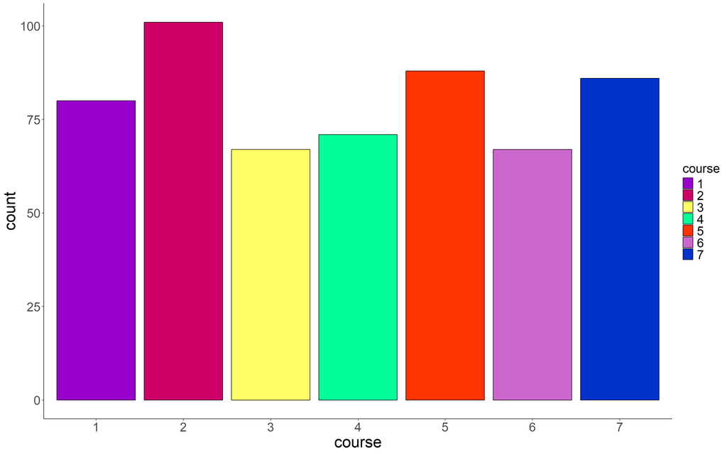

```r
theme_custom <- theme(
    axis.text = element_text(size = 20),
    axis.title = element_text(size = 25),
    legend.title = element_text(size = 20),
    legend.text = element_text(size = 20)
  )

first_barplot <- ggplot(hogwarts)+
  geom_bar(aes(x = course, fill=course), colour = "black")+
  scale_fill_manual(values = c("1" = "#9900CC",
                               "2" = "#CC0066",
                               "3" = "#FFFF66",
                               "4" = "#00FF99",
                               "5" = "#FF3300",
                               "6" = "#CC66CC",
                               "7" = "#0033CC"))+
  theme_classic()+theme_custom

first_barplot
```

#### Второй график

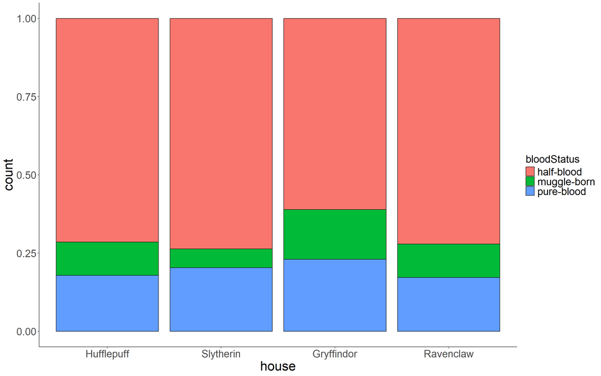

```r
second_barplot <- ggplot(hogwarts)+
  geom_bar(aes(x = fct_infreq(house),
               fill = bloodStatus),
           colour = "black",
           position = "fill")+
  scale_x_discrete(name = "house")+
  theme_classic()+theme_custom

second_barplot
```

#### Третий график

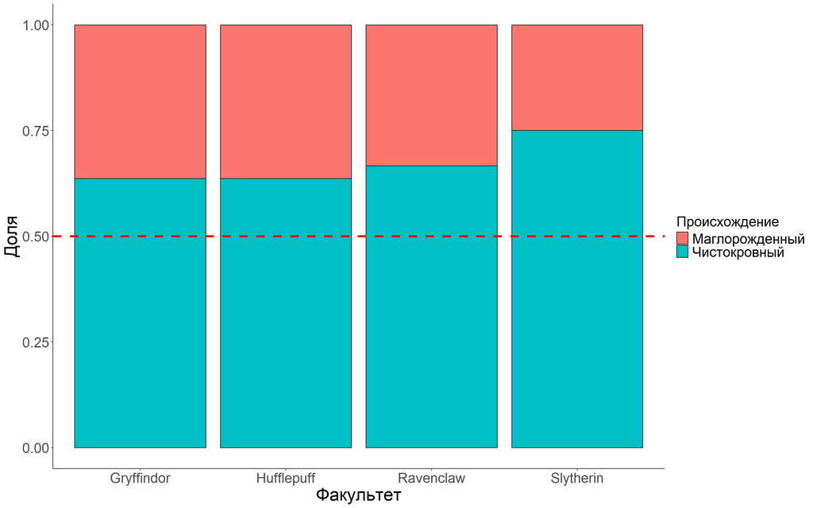

```r
third_barplot <- hogwarts |>
  filter(bloodStatus == c("pure-blood", "muggle-born")) |>
  ggplot()+
  geom_bar(aes(x = fct_infreq(house),
               fill = bloodStatus),
           colour = "black",
           position = "fill")+
  scale_x_discrete(name = "Факультет")+
  labs(x = "Факультет",
       y = "Доля",
       fill = "Происхождение")+
  scale_fill_discrete(labels = c("Маглорожденный", "Чистокровный"))+
  theme_classic()+theme_custom+
  geom_hline(yintercept = 0.5, linetype = "dashed", color = "red", size = 1.5)

third_barplot
```

### Боксплоты

#### Первый график

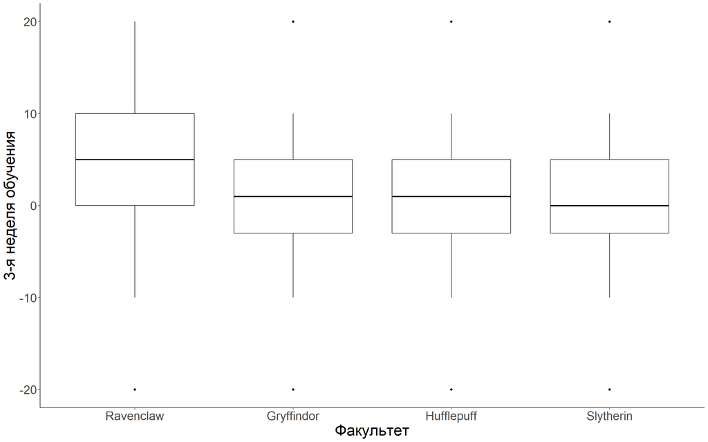

```r
first_boxplot <- ggplot(hogwarts)+
  geom_boxplot(aes(y = `week_3`,
                   x = fct_reorder(house, week_3, .desc=TRUE)),
               colour = "black")+
  scale_x_discrete(name = "Факультет")+
  labs(x = "Факультет",
       y = "3-я неделя обучения")+
  theme_classic()+
  theme_custom
first_boxplot
```

#### Второй график

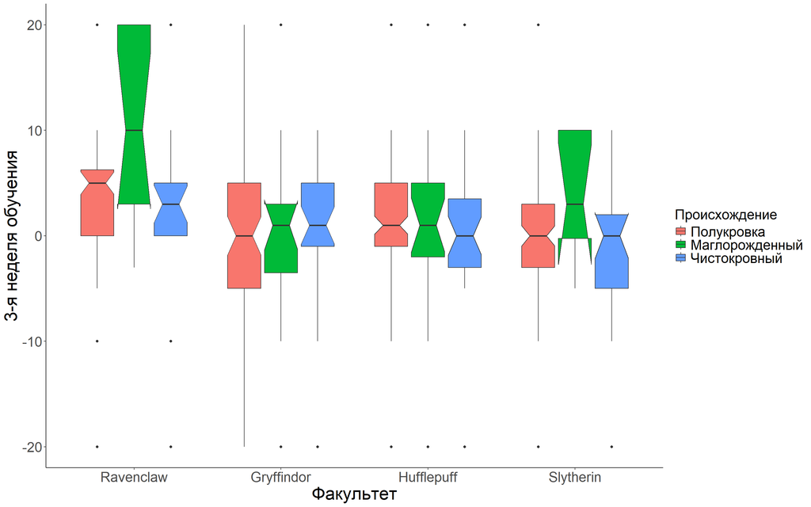

```r
knitr::opts_chunk$set(fig.width=14, fig.height=14)

 second_boxplot <- ggplot(hogwarts)+
  geom_boxplot(aes(y = `week_3`,
                   x = fct_reorder(house, week_3, .desc=TRUE),
         fill= bloodStatus), notch = TRUE)+
  scale_x_discrete(name = "Факультет")+
  labs(x = "Факультет",
       y = "3-я неделя обучения",
       fill = "Происхождение")+
    scale_fill_discrete(labels = c("Полукровка", "Маглорожденный", "Чистокровный"))+
  theme_classic()+
  theme_custom

 second_boxplot
```

#### Третий график

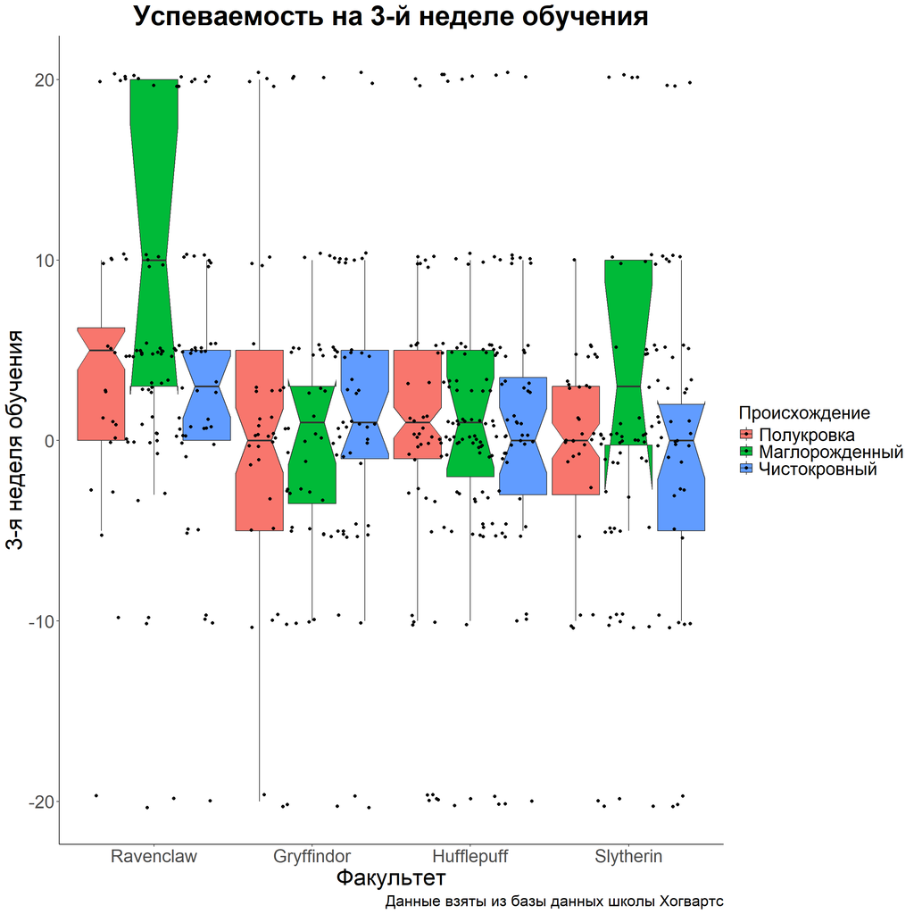

```r
knitr::opts_chunk$set(fig.width=14, fig.height=14)

third_boxplot <- hogwarts |> ggplot(aes(y = `week_3`,
                   x = fct_reorder(house, week_3, .desc=TRUE),
         fill= bloodStatus))+
  geom_boxplot(notch = TRUE, outliers = FALSE, width = 4,
               linewidth = 0.5)+
  scale_x_discrete(name = "Факультет")+
  labs(title = "Успеваемость на 3-й неделе обучения",
       x = "Факультет",
       y = "3-я неделя обучения",
       fill = "Происхождение",
       caption = "Данные взяты из базы данных школы Хогвартс")+
    scale_fill_discrete(labels = c("Полукровка", "Маглорожденный", "Чистокровный"))+
   geom_jitter()+
  theme_classic()+
  theme_custom+
  theme(plot.title = element_text(size = 30, face = "bold",  hjust = 0.5), plot.caption= element_text(size = 17))

third_boxplot
```

### Разное

#### Lollipop-plot

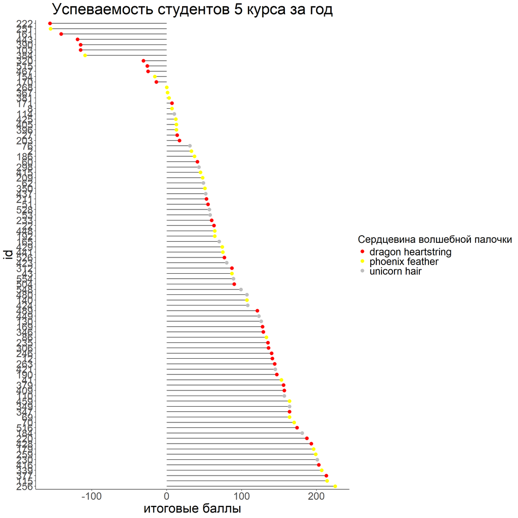

```r
wand_colors <- c("dragon heartstring" = "red",
                "phoenix feather" = "yellow",
                "unicorn hair" = "grey")

  lollipop_plot <- hogwarts |>
  filter(course == 5) |>
  mutate(id = as.factor(id)) |>
  ggplot()+
  geom_segment(aes(x = 0,
                   xend = result,
                   y = fct_reorder(id, result, .desc = TRUE),
                   yend = fct_reorder(id, result, .desc = TRUE)))+
  geom_point(aes(x = result,
                 y = fct_reorder(id, result, .desc = TRUE), color=wandCore), size = 3)+
  scale_color_manual(values = wand_colors) +
  labs(title = "Успеваемость студентов 5 курса за год",
       x = "итоговые баллы",
       y = "id",
       color = "Сердцевина волшебной палочки")+
  theme_classic()+
  theme_custom+
    theme(
    plot.title = element_text(size = 30, hjust = 0.5))

lollipop_plot
```

#### Гистограмма

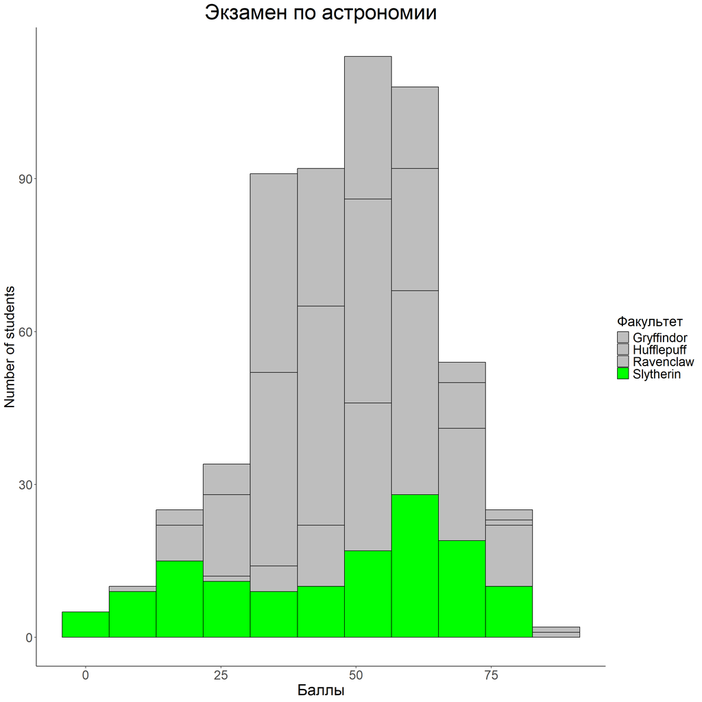

```r
histogram <- ggplot(hogwarts)+
  geom_histogram(aes(x = `Astronomy exam`, fill=house),
                 colour = "black",
                 bins = ceiling(log2(nrow(hogwarts))+1))+
  labs(title = "Экзамен по астрономии",
       x = "Баллы",
       y = "Number of students", # Изменяем название оси y
       fill = "Факультет")+
  scale_fill_manual(values = c("Gryffindor" = "grey",
                              "Hufflepuff" = "grey",
                              "Ravenclaw" = "grey",
                              "Slytherin" = "green"))+
  theme_classic()+
  theme(axis.text = element_text(size = 18),
        axis.title.y = element_text(size = 20),
        axis.title.x = element_text(size = 22),
        legend.text = element_text(size = 18),
        legend.title = element_text(size = 20),
        plot.title = element_text(size = 30, hjust = 0.5))

histogram
```

#### Модифицированный боксплот

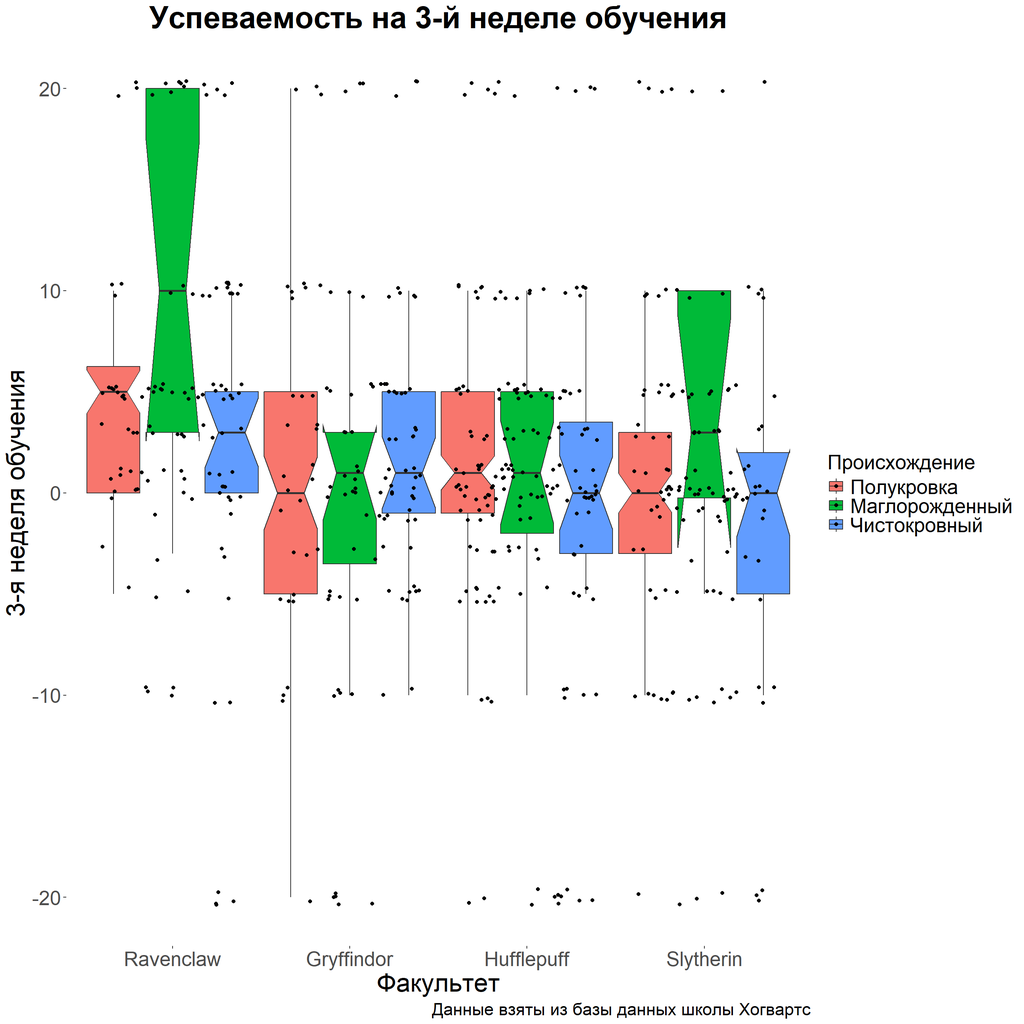

```r
theme_custom_onemore <- theme(
    axis.text = element_text(size = 20),
    axis.title = element_text(size = 25),
    legend.title = element_text(size = 20),
    legend.text = element_text(size = 20),
    panel.background = element_rect(fill = "white"),
    plot.background = element_rect(fill = "white")
)


modified_third_boxplot <- hogwarts |> ggplot(aes(y = `week_3`,
                   x = fct_reorder(house, week_3, .desc=TRUE),
         fill= bloodStatus))+
  geom_boxplot(notch = TRUE, outliers = FALSE, width = 4,
               linewidth = 0.5)+
  scale_x_discrete(name = "Факультет")+
  labs(title = "Успеваемость на 3-й неделе обучения",
       x = "Факультет",
       y = "3-я неделя обучения",
       fill = "Происхождение",
       caption = "Данные взяты из базы данных школы Хогвартс")+
    scale_fill_discrete(labels = c("Полукровка", "Маглорожденный", "Чистокровный"))+
   geom_jitter()+
  theme_custom_onemore+
  theme(plot.title = element_text(size = 30, face = "bold",  hjust = 0.5), plot.caption= element_text(size = 17))

modified_third_boxplot
```

### Фасетирование

#### Способы фасетирования для визуализации разных типов графиков

Для визуализации гистограммы лучше использовать способ фасетирования по строкам. При фасетировании по строкам гистограммы каждой группы данных располагаются одна под другой, что позволяет легко сравнивать формы распределений и выявлять различия между группами.

Для визуализации violin-plot лучше использовать способ фасетирования по столбцам. Violin-plot часто используют для визуализации различий в медианах и формах распределения. Фасетирование по столбцам позволяет легко сравнивать медианы различных групп, так как они расположены рядом друг с другом.

Если нужно показать распределение данных внутри каждой группы - лучше фасетировать по строкам. Если нужно сравнить распределения между группами - по столбцам. Фасетирование по строкам для гистограмм позволяет лучше сравнивать формы распределений, а фасетирование по столбцам для violin-plot - медианы и формы распределения разных групп.

Но не всегда есть однозначно правильный способ фасетирования. Иногда может быть лучше использовать фасетирование по строкам для violin-plot или по столбцам для гистограмм в зависимости от конкретного набора данных и целей визуализации. Важно экспериментировать с разными способами фасетирования, чтобы найти самый эффективный и наглядный способ визуализации ваших данных.

#### Фасетирование гистограммы

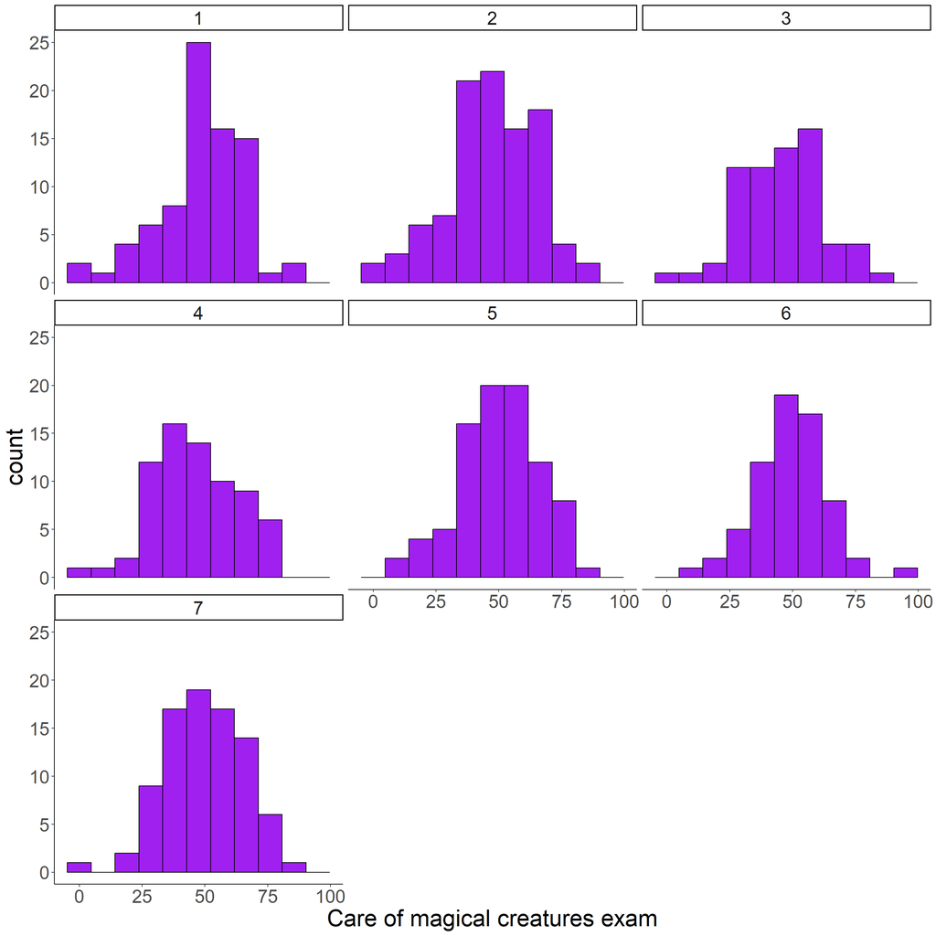

```r
facet_histogram <- ggplot(hogwarts)+
  geom_histogram(aes(x = `Care of magical creatures exam`),
                 fill = "purple",
                 colour = "black",
                 bins = ceiling(log2(nrow(hogwarts))+1))+
  facet_wrap(vars(course))+
  theme_classic()+
  theme(strip.text = element_text(size = 20))+
  theme_custom

facet_histogram
```

#### Плотность вероятности, фасетирование

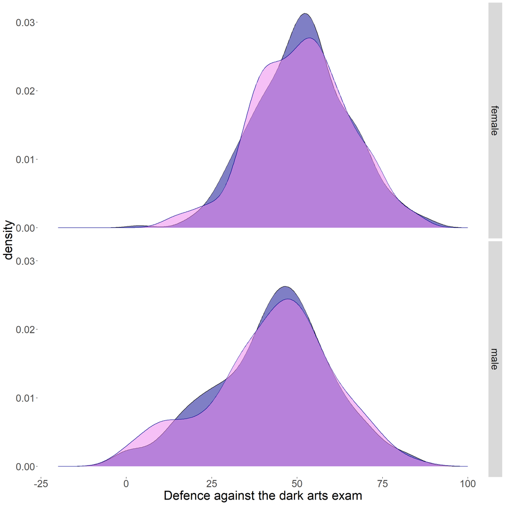

```r
facet_density <- ggplot(hogwarts)+
  geom_density(aes(x = `Defence against the dark arts exam`),
               fill = "darkblue",
               colour = "black",
               alpha = 0.5)+
  geom_density(aes(x = `Herbology exam`),
               fill = "violet",
               colour = "darkblue",
               alpha = 0.5)+
  xlim(c(-20, 100))+
  facet_grid(sex~.)+
  theme(strip.text = element_text(size = 20))+
  theme_custom_onemore

facet_density
```